# Cherashore Survey Analysis

# **2. Activities**

Did you know about any of these existing programs at Cherashore? *(Select All That Apply)*

### 2.1 Plot

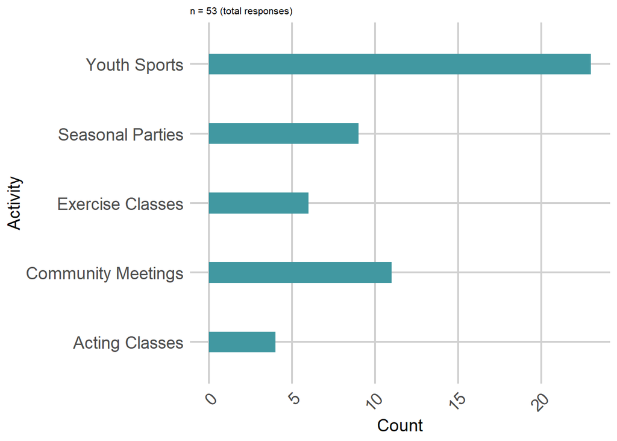

```r
summary <- dat %>%
  group_by(X3Commute) %>%
  filter(X3Commute != "") %>%
  summarise(count=n()) %>%
  mutate(X3Commute_perc = (count/sum(count))*100)
ggplot(dat %>%
         select(matches("X2Available.Program_")) %>%
         gather(key = "variable", value = "value") %>%
         filter(value != ""))+
  geom_bar(aes(value, fill=value), width = 0.3, fill="#4198A1")+
  labs(
    y="Count",
    x="Activity",
    subtitle="n = 53 (total responses)"
  )+
  coord_flip()+
  plotTheme12ptY
```

### 2.2 Table

```r
dat %>%
         select(matches("X2Available.Program_")) %>%
         gather(key = "variable", value = "value") %>%
         filter(value != "") %>%
  group_by(value) %>%
  tally()%>%
  kable(col.names = NULL)%>%
  kable_styling(position = "center")
```

| Acting Classes | 4 |
| --- | --- |
| Community Meetings | 11 |
| Exercise Classes | 6 |
| Seasonal Parties | 9 |
| Youth Sports | 23 |

# **3. Access**

How do you get to Cherashore?

### 3.1 Plot Commute

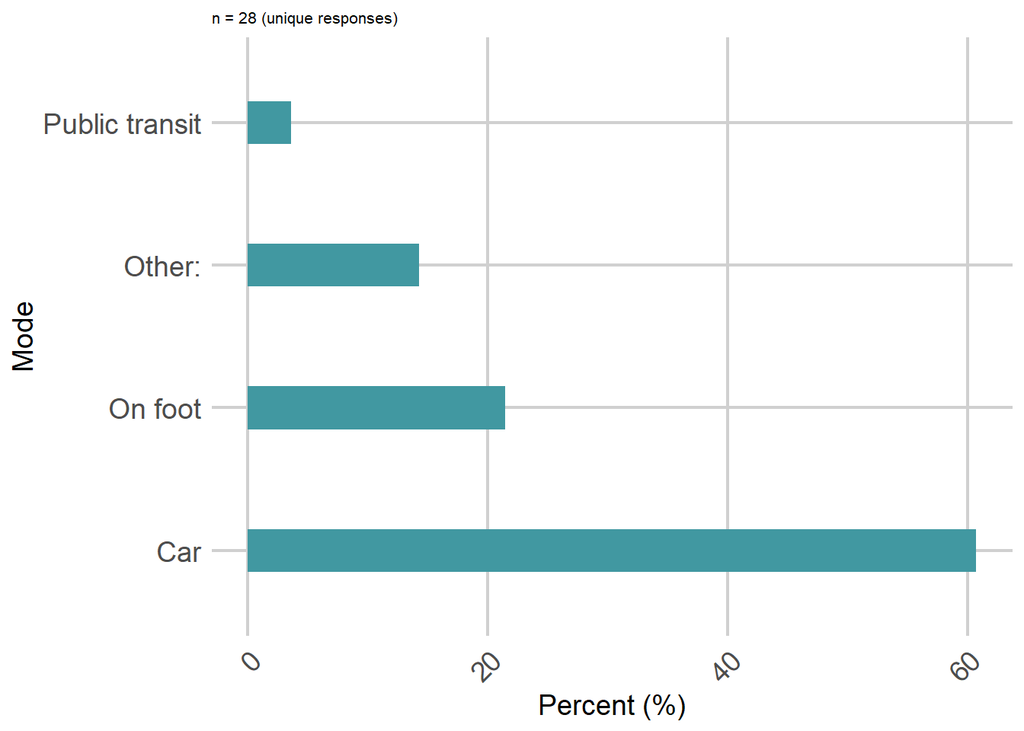

```r
summary <- dat %>%
  group_by(X3Commute) %>%
  filter(X3Commute != "") %>%
  summarise(count=n()) %>%
  mutate(X3Commute_perc = (count/sum(count))*100)

ggplot(summary %>%
         select(X3Commute_perc, X3Commute),
         aes(x=X3Commute_perc, y=X3Commute)) +
  geom_bar(stat="identity", width = 0.3, fill="#4198A1")+
  labs(
    x="Percent (%)",
    y="Mode",
    subtitle="n = 28 (unique responses)"
  )+
  plotTheme12ptY
```

### 3.2 ‘Other’ Commute responses

n = 1

```r
dat %>%
  select(X3Commute_5_TEXT) %>%
  filter(X3Commute_5_TEXT != "") %>%
  kable(col.names = NULL)%>%
  kable_styling()
```

| On foot and sometimes car |
| --- |

# **4. Proximity to Cherashore**

How far do you live from Cherashore?

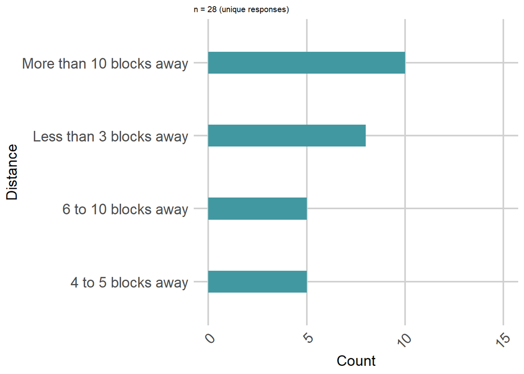

```r
ggplot(dat %>%
         select(X4Proximity) %>%
         gather(key = "variable", value = "value") %>%
         filter(value != ""))+
  geom_bar(aes(value, fill=value), width = 0.3, fill="#4198A1")+
  ylim(0,15)+
  labs(
    y="Count",
    x="Distance",
    subtitle="n = 28 (unique responses)"
  )+
  coord_flip()+
  plotTheme12ptY
```

# **5. Future programming**

What kind of programming do you see yourself participating in Cherashore? *(Please select all that apply)*

### 5.1 Plot

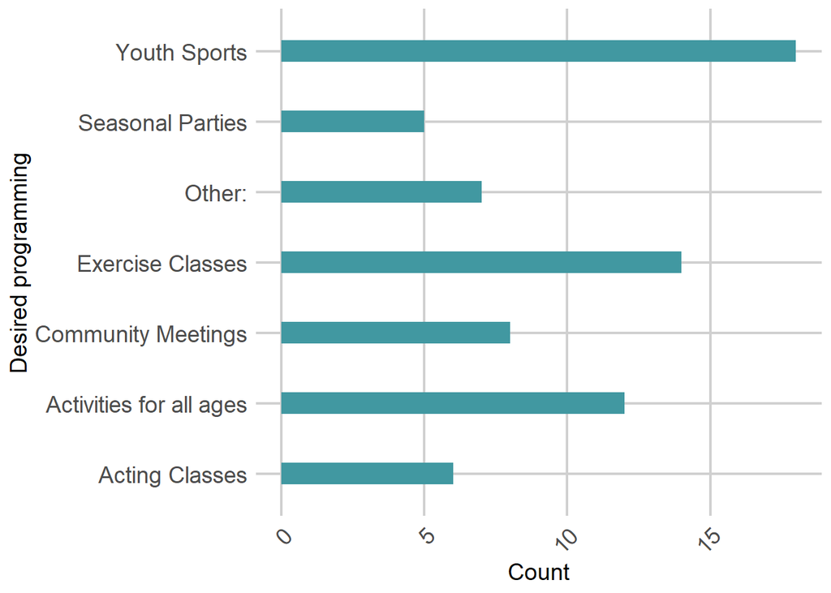

```r
ggplot(dat %>%
         select(matches("X5Programming_")) %>%
         select(-X5Programming_6_TEXT) %>%
         gather(key = "variable", value = "value") %>%
         filter(value != ""))+
  geom_bar(aes(value, fill=value), width = 0.3, fill="#4198A1")+
  ylab("Count")+
  xlab("Desired programming")+
  coord_flip()+
  plotTheme12ptY
```

### 5.2 ‘Other’ Programming responses

```r
dat %>%
  select(X5Programming_6_TEXT) %>%
  filter(X5Programming_6_TEXT != "") %>%
  kable(caption="Other Programming responses", col.names = NULL)%>%
  kable_styling()
```

Other Programming responses

| More opportunities for kids, resources, safe space |
| --- |
| Senior bingo, arts and crafts, kids tutoring (winter), movie nights (inside) |
| Arts and crafts, cooking class, yoga, dance |
| Lunches |
| Clean ups |

# **6. Amenities**

### 6.1 Future amenities

What kinds of amenities/spaces would you like to see in Cherashore? *(Please select all that apply)*

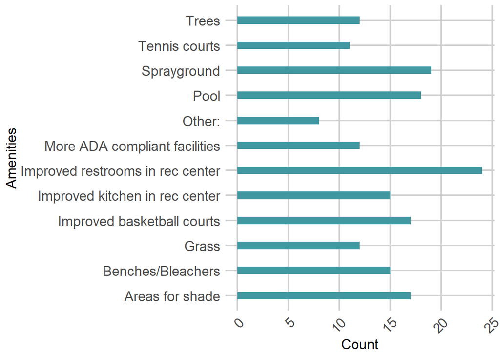

```r
ggplot(dat %>%
         select(matches("X6Design_")) %>%
         select(-X6Design_12_TEXT) %>%
         gather(key = "variable", value = "value") %>%
         filter(value != ""))+
  geom_bar(aes(value, fill=value), width = 0.3, fill="#4198A1")+
  ylab("Count")+
  xlab("Amenities")+
  coord_flip()+
  plotTheme12ptY
```

### 6.2 ‘Other’ Amenities

```r
dat %>%
  select(X6Design_12_TEXT) %>%
  filter(X6Design_12_TEXT != "") %>%
  kable(caption="Other Amenities responses", col.names = NULL)%>%
  kable_styling()
```

Other Amenities responses

| Field |
| --- |
| Security parking lightig |
| Trash cans |
| New goal posts, playground!!! Better fencing |
| Improved playground and play areas |
| Lunches |
| Water fountains/ removal of groundhogs |

# **7. Sentiment**

Please indicate if you agree with the following statements:

### 7.1 *“I feel safe at Cherashore”*

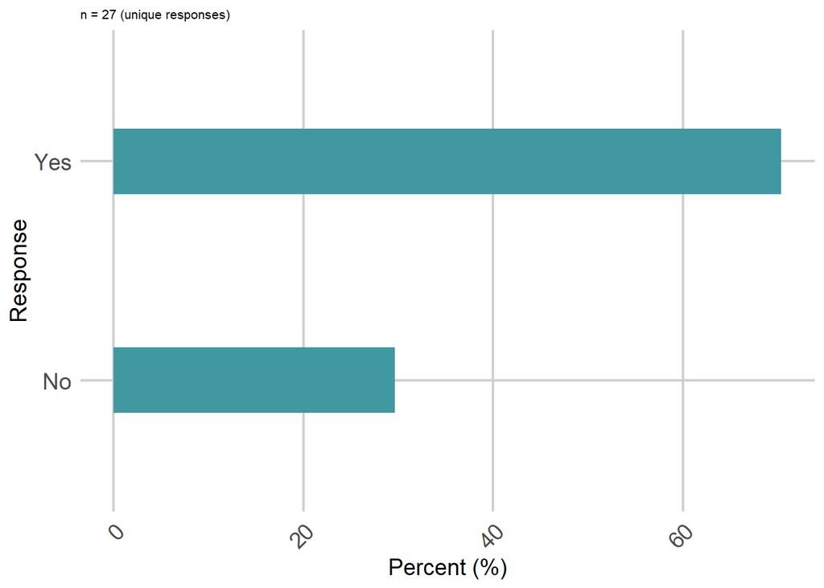

```r
summary <- dat %>%
  group_by(X7Safety) %>%
  filter(X7Safety != "") %>%
  summarise(count=n()) %>%
  mutate(X7Safety_perc = (count/sum(count))*100)

ggplot(summary %>%
         select(X7Safety_perc, X7Safety),
         aes(x=X7Safety_perc, y=X7Safety)) +
  geom_bar(stat="identity", width = 0.3, fill="#4198A1")+
  labs(
    x="Percent (%)",
    y="Response",
    subtitle="n = 27 (unique responses)"
  )+
  plotTheme12ptY
```

### Cross tabulation by age

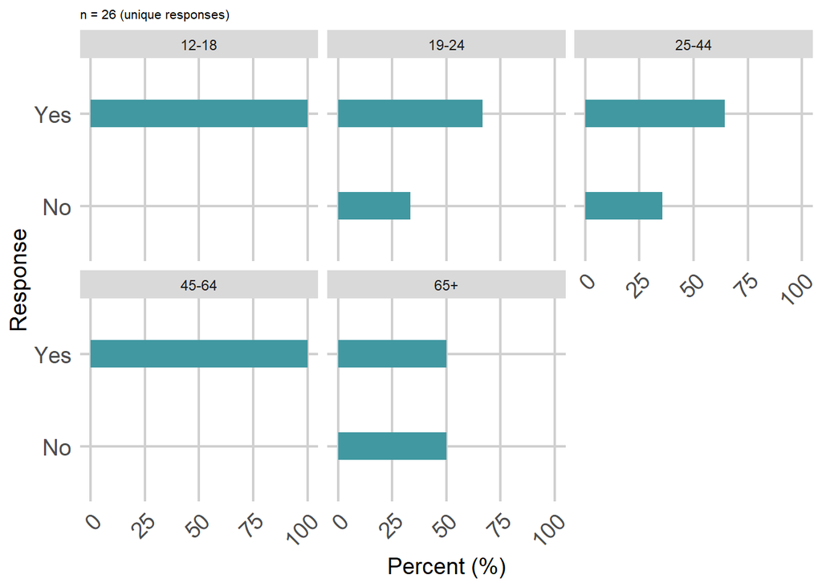

### 7.2 *“I feel unsafe at Cherashore because…”*

```r
dat %>%
  select(X8Safety) %>%
  filter(X8Safety != "") %>%
  kable(col.names = NULL)%>%
  kable_styling()
```

| Because they do be shooting here sometimes |
| --- |
| No police |
| People hanging around don’t look positive |

### 7.3 *“Cherashore is a place that I can gather with friends and family”*

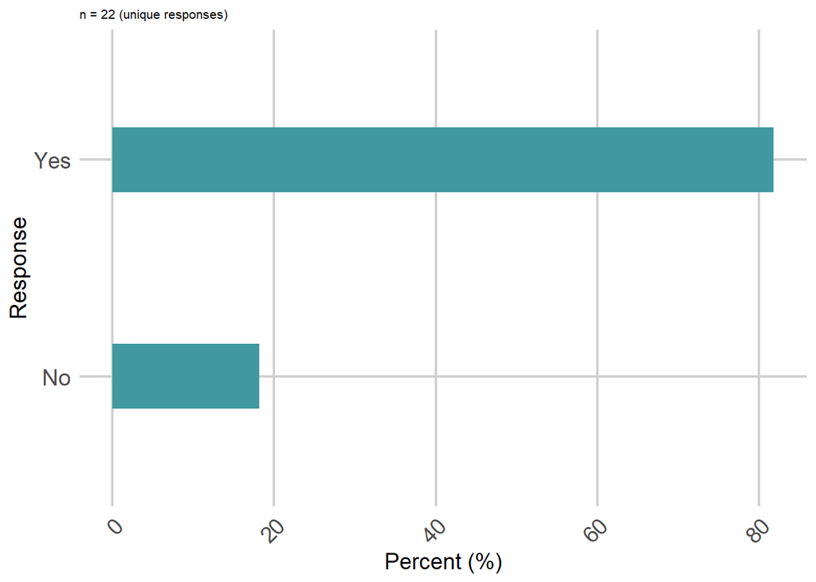

```r
summary <- dat %>%
  group_by(X9Access) %>%
  filter(X9Access != "") %>%
  summarise(count=n()) %>%
  mutate(X9Access_perc = (count/sum(count))*100)

ggplot(summary %>%
         select(X9Access_perc, X9Access),
         aes(x=X9Access_perc, y=X9Access)) +
  geom_bar(stat="identity", width = 0.3, fill="#4198A1")+
  labs(
    x="Percent (%)",
    y="Response",
    subtitle="n = 22 (unique responses)"
  )+
  plotTheme12ptY
```

### Cross tabluation by age

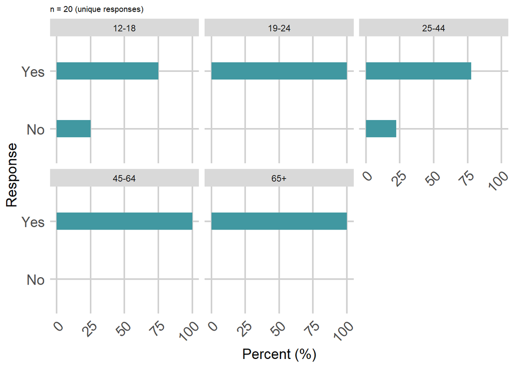

```r
summary <- dat %>%
  group_by(X9Access, X20Age) %>%
  filter(X9Access != "" & X20Age != "") %>%
  summarise(count=n()) %>%
  group_by(X20Age) %>%
  mutate(X9Access_perc = (count/sum(count))*100)

ggplot(summary %>%
         select(X9Access_perc, X9Access, X20Age),
         aes(x=X9Access_perc, y=X9Access)) +
  geom_bar(stat="identity", width = 0.3, fill="#4198A1")+
  facet_wrap(~X20Age) +
  labs(
    x="Percent (%)",
    y="Response",
    subtitle="n = 20 (unique responses)"
  )+
  plotTheme12ptY
```

### Cross tabulation by proximity

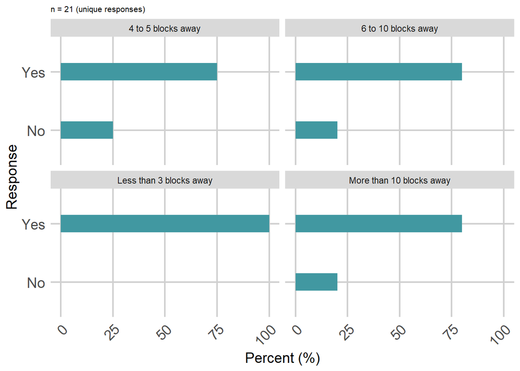

```r
summary <- dat %>%
  group_by(X9Access, X4Proximity) %>%
  filter(X9Access != "" & X4Proximity != "") %>%
  summarise(count=n()) %>%
  group_by(X4Proximity) %>%
  mutate(X9Access_perc = (count/sum(count))*100)

ggplot(summary %>%
         select(X9Access_perc, X9Access, X4Proximity),
         aes(x=X9Access_perc, y=X9Access)) +
  geom_bar(stat="identity", width = 0.3, fill="#4198A1")+
  facet_wrap(~X4Proximity) +
  labs(
    x="Percent (%)",
    y="Response",
    subtitle="n = 21 (unique responses)"
  )+
  plotTheme12ptY
```

### 7.4 *“Cherashore is a place that I cannot gather with friends and family because…”*

```r
dat %>%
  select(X10Access) %>%
  filter(X10Access != "") %>%
  kable(col.names = NULL)%>%
  kable_styling()
```

| I don’t invite them. |
| --- |
| Not enough resources |
| There are no activities |

### 7.5 *“I believe I have a say in the decisions that affect Cherashore”*

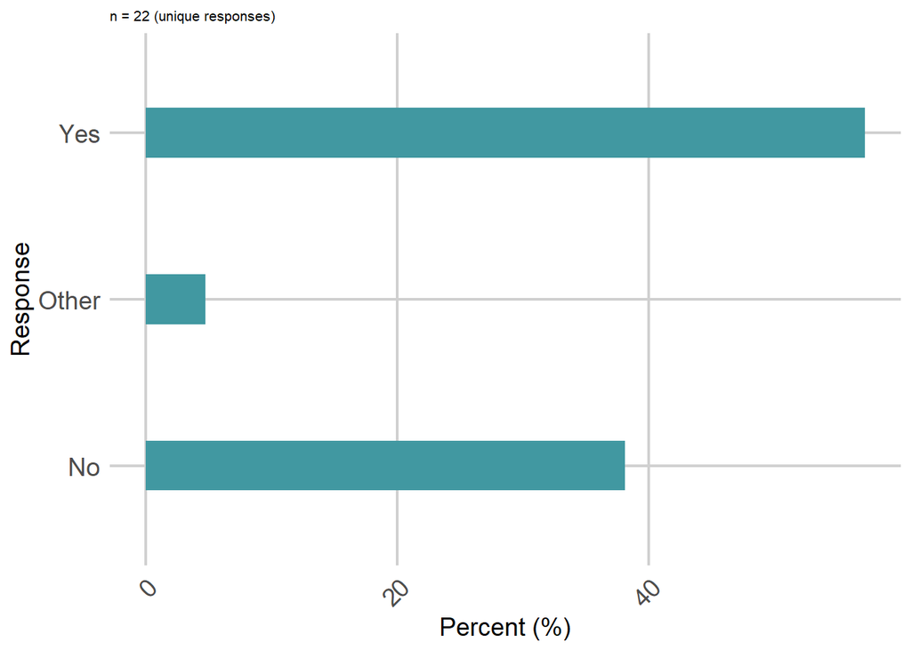

```r
summary <- dat %>%
  group_by(X11SiteOwnership) %>%
  filter(X11SiteOwnership != "") %>%
  summarise(count=n()) %>%
  mutate(X11SiteOwnership_perc = (count/sum(count))*100)

ggplot(summary %>%
         select(X11SiteOwnership_perc, X11SiteOwnership),
         aes(x=X11SiteOwnership_perc, y=X11SiteOwnership)) +
  geom_bar(stat="identity", width = 0.3, fill="#4198A1")+
  labs(
    x="Percent (%)",
    y="Response",
    subtitle="n = 22 (unique responses)"
  )+
  plotTheme12ptY
```

### Cross tabulation by proximity

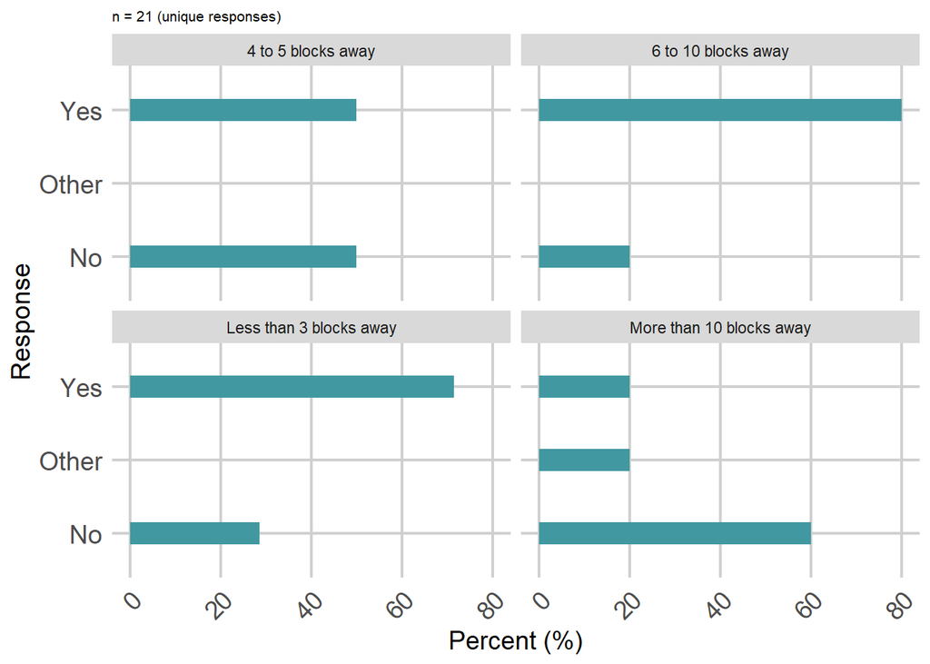

```r
summary <- dat %>%
  group_by(X11SiteOwnership, X4Proximity) %>%
  filter(X11SiteOwnership != "" & X4Proximity != "") %>%
  summarise(count=n()) %>%
  group_by(X4Proximity) %>%
  mutate(X11SiteOwnership_perc = (count/sum(count))*100)

ggplot(summary %>%
         select(X11SiteOwnership_perc, X11SiteOwnership, X4Proximity),
         aes(x=X11SiteOwnership_perc, y=X11SiteOwnership)) +
  geom_bar(stat="identity", width = 0.3, fill="#4198A1")+
  facet_wrap(~X4Proximity) +
  labs(
    x="Percent (%)",
    y="Response",
    subtitle="n = 21 (unique responses)"
  )+
  plotTheme12ptY
```

# **8. Barriers**

Is there anything that keeps you from visiting Cherashore? *(Please select all that apply)*

### 8.1 Plot

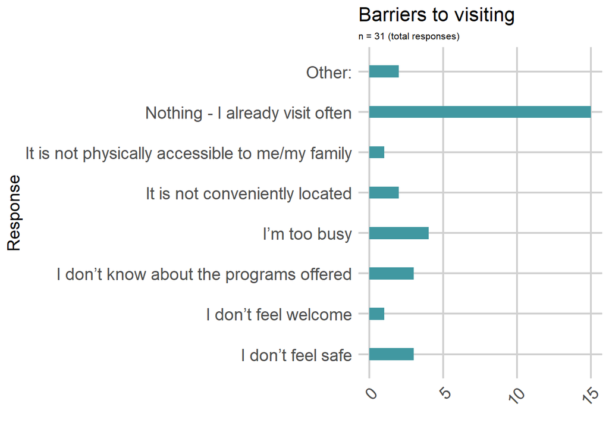

```r
ggplot(dat %>%
         select(matches("X12SiteBarriers1_")) %>%
         select(-X12SiteBarriers1_9_TEXT) %>%
         gather(key = "variable", value = "value") %>%
         filter(value != ""))+
  geom_bar(aes(value, fill=value), width = 0.3, fill="#4198A1")+
 labs(
   x = "Response",
   y = "",
   title = "Barriers to visiting",
   subtitle = "n = 31 (total responses)"
 ) +
  coord_flip()+
  plotTheme12ptY
```

### 8.2 ‘Other’ responses

```r
dat %>%
  select(X12SiteBarriers1_9_TEXT) %>%
  filter(X12SiteBarriers1_9_TEXT != "") %>%
  kable(caption="Barriers to visiting", col.names = NULL) %>%
  kable_styling()
```

Barriers to visiting

| Shade |
| --- |
| Gangs not bad, parents present |

### 8.3 Cont.

Tell us more about why

```r
dat %>%
  select(X13SiteBarriers2) %>%
  filter(X13SiteBarriers2 != "") %>%
  kable(col.names = NULL) %>%
  kable_styling()
```

| For baseball practice |
| --- |
| I work |
| Not enough things to participate in |
| No |
| Was important to me as a kid; lunches counselors during the day |
| Will come if the pool and rec center are open |

# **9. Incentives to visit**

Is there anything that would make you come to Cherashore more?

### 9.1 Plot

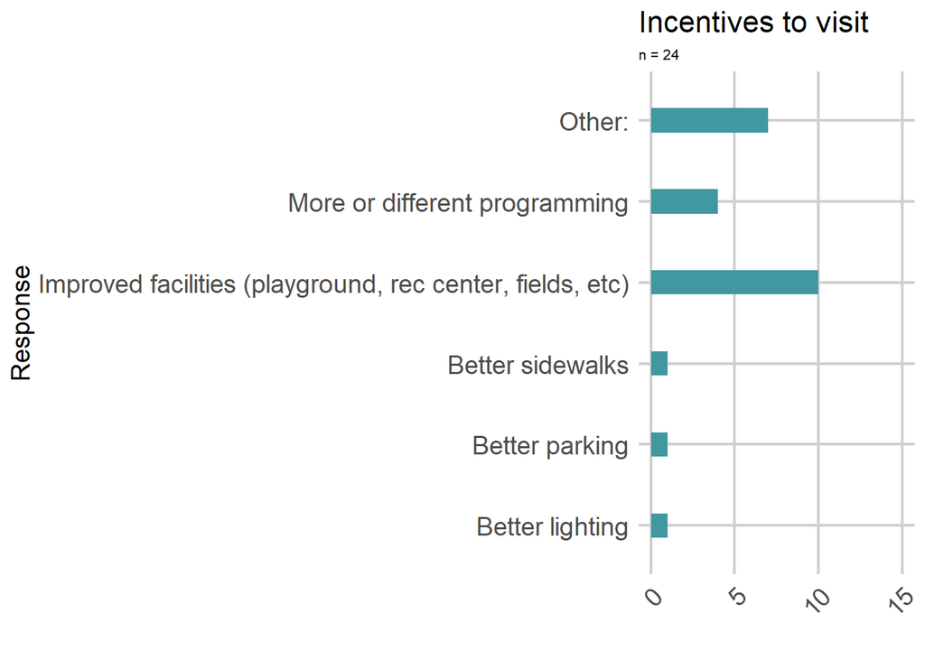

```r
ggplot(dat %>%
         select(X14SiteBarriers3) %>%
          gather(key = "variable", value = "value") %>%
         filter(value != "")) +
         geom_bar(aes(value, fill=value), width = 0.3, fill="#4198A1")+
         labs(
          x = "Response",
          y = "",
          title = "Incentives to visit",
          subtitle = "n = 24"
          ) +
        ylim(0,15)+
        coord_flip()+
        plotTheme12ptY
```

### 9.2 ‘Other’ responses

```r
dat %>%
  select(X14SiteBarriers3_7_TEXT) %>%
  filter(X14SiteBarriers3_7_TEXT != "") %>%
  kable(col.names = NULL) %>%
  kable_styling()
```

| Already come often |
| --- |
| No |
| Lighting and parking |
| Nothing |
| Hours, lighting |
| I actually work the same hours the facility is open |
| Food stand |

# **10. Neighborhood connections**

Which neighborhood public spaces do people usually gather with their family and friends?

### 10.1 Public spaces

```r
dat %>%
  select(X15NeighborhoodConnec) %>%
  filter(X15NeighborhoodConnec != "") %>%
  kable(caption="Neighborhood connections", col.names = NULL) %>%
  kable_styling(position="center") %>%
  scroll_box(width = "650px", height = "400px")
```

Neighborhood connections

| Fisher park, kimball park, high schools |
| --- |
| Chesshore park |
| Here and sturgis |
| Kelly dr |
| Park |
| Parks |
| Porch |
| Senior centers |
| Cherashore |
| Porch |
| The pool. |
| No. Rec center needs to be bigger |
| Pools |
| Finley |
| Playground |
| This is only close one in the neighborhood |
| Parks and playground |
| Chestnut Hill |
| Suburbs |
| None |
| Finley |
| Near Morris estates |

### 10.2 Local organizations

Are you involved in any local organizations?

```r
dat %>%
  select(X16NeighborhoodConnec) %>%
  filter(X16NeighborhoodConnec != "") %>%
  kable(caption="Involvement with local organizations", col.names = NULL) %>%
  kable_styling(position = "center") %>%
  scroll_box(width = "650px", height = "400px")
```

Involvement with local organizations

| Yes, volunteering |
| --- |
| No |
| No |
| No |
| No |
| Cherashore |
| No |
| No |
| Yes |
| No |
| No |
| Cherashore Advisory board, volunteer mentor or police liaison |
| No |
| No |
| Yes the pool |
| No |
| Votes at cherashore, wants to be block captain since they don’t have one now |
| Yes |
| Vet volunteering |
| No |
| No |
| No |

# **11. Demographics**

### 11.1 Location

Zipcode of survey respondents

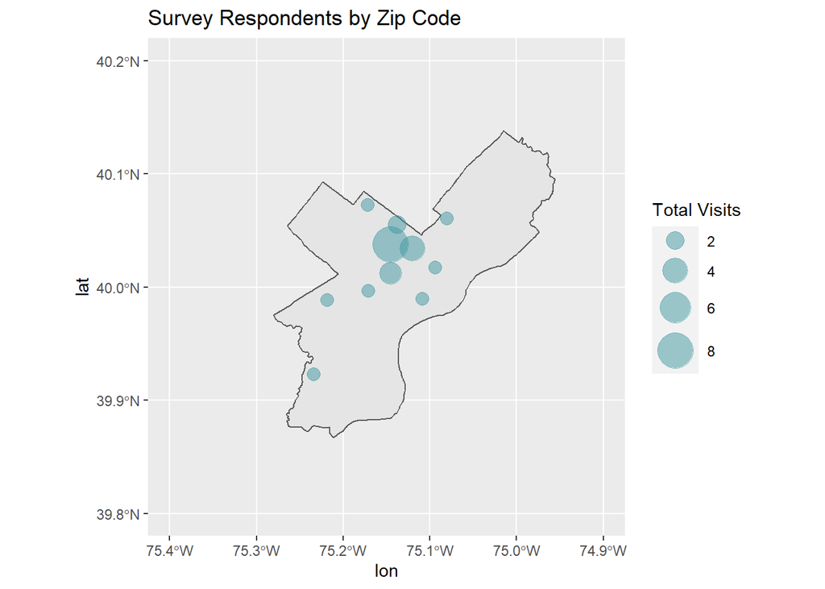

### 11.2 Gender

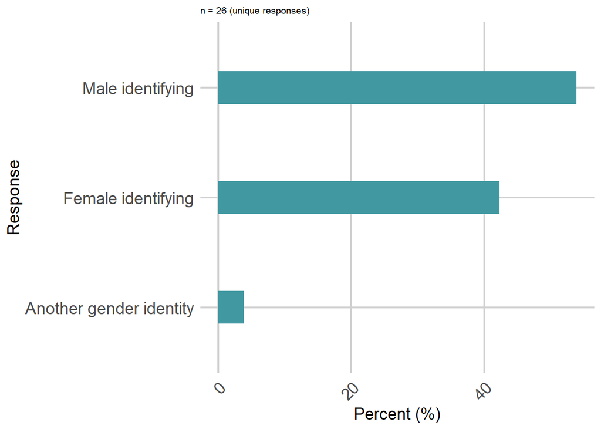

```r
summary <- dat %>%
  group_by(X18Gender) %>%
  filter(X18Gender != "") %>%
  summarise(count=n()) %>%
  mutate(X18Gender_perc = (count/sum(count))*100)

ggplot(summary %>%
         select(X18Gender_perc, X18Gender),
         aes(x=X18Gender_perc, y=X18Gender)) +
  geom_bar(stat="identity", width = 0.3, fill="#4198A1")+
  labs(
    x="Percent (%)",
    y="Response",
    subtitle="n = 26 (unique responses)"
  )+
  plotTheme12ptY
```

### 11.3 Race/Ethnicity

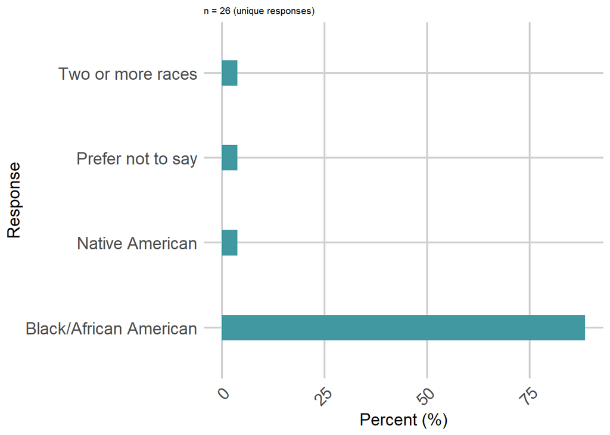

```r
summary <- dat %>%
  group_by(X19Race.Ethnicity) %>%
  filter(X19Race.Ethnicity != "") %>%
  summarise(count=n()) %>%
  mutate(X19Race.Ethnicity_perc = (count/sum(count))*100)

ggplot(summary %>%
         select(X19Race.Ethnicity_perc, X19Race.Ethnicity),
         aes(x=X19Race.Ethnicity_perc, y=X19Race.Ethnicity)) +
  geom_bar(stat="identity", width = 0.3, fill="#4198A1")+
  labs(
    x="Percent (%)",
    y="Response",
    subtitle="n = 26 (unique responses)"
  )+
  plotTheme12ptY
```

### 11.4 Age

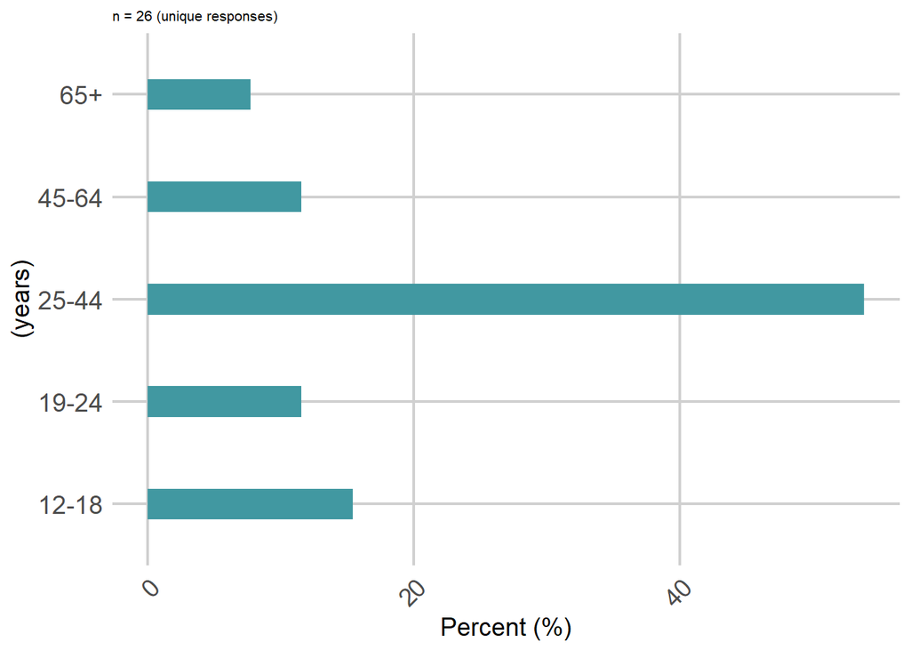

```r
summary <- dat %>%
  group_by(X20Age) %>%
  filter(X20Age != "") %>%
  summarise(count=n()) %>%
  mutate(X20Age_perc = (count/sum(count))*100)

ggplot(summary %>%
         select(X20Age_perc, X20Age),
         aes(x=X20Age_perc, y=X20Age)) +
  geom_bar(stat="identity", width = 0.3, fill="#4198A1")+
  labs(
    x="Percent (%)",
    y="(years)",
    subtitle="n = 26 (unique responses)"
  )+
  plotTheme12ptY
```

### 11.5 Parental status

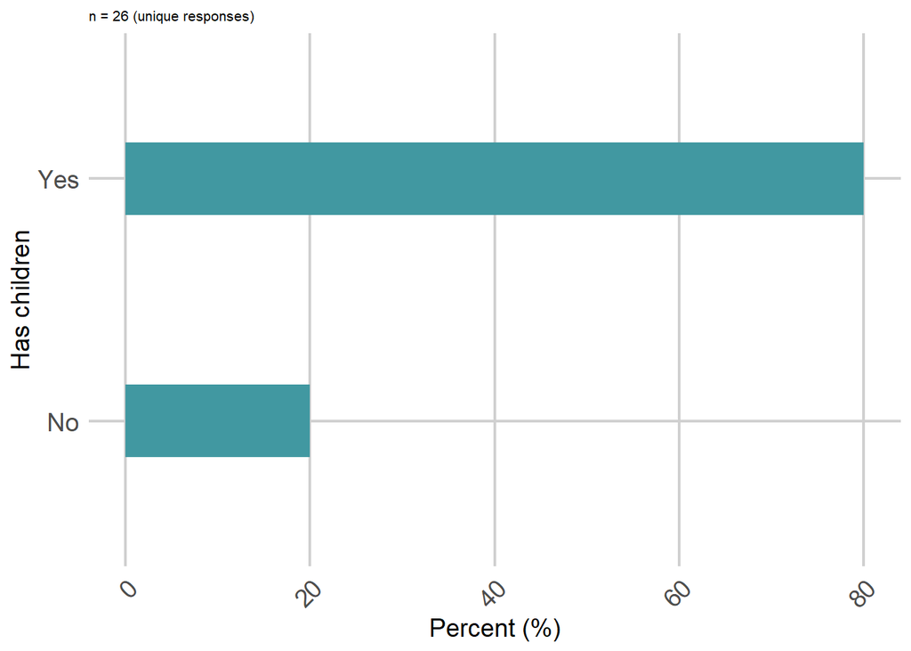

```r
summary <- dat %>%
  group_by(X21ParentalStatus) %>%
  filter(X21ParentalStatus != "") %>%
  summarise(count=n()) %>%
  mutate(X21ParentalStatus_perc = (count/sum(count))*100)

ggplot(summary %>%
         select(X21ParentalStatus_perc, X21ParentalStatus),
         aes(x=X21ParentalStatus_perc, y=X21ParentalStatus)) +
  geom_bar(stat="identity", width = 0.3, fill="#4198A1")+
  labs(
    x="Percent (%)",
    y="Has children",
    subtitle="n = 26 (unique responses)"
  )+
  plotTheme12ptY
```

### 11.6 English proficiency

Is English your native language?

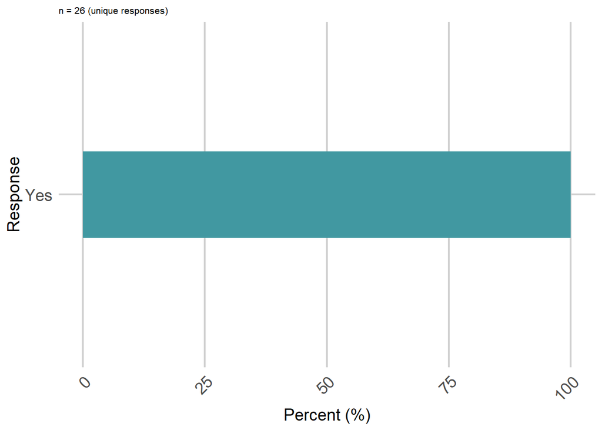

```r
summary <- dat %>%
  group_by(X22Language) %>%
  filter(X22Language != "") %>%
  summarise(count=n()) %>%
  mutate(X22Language_perc = (count/sum(count))*100)

ggplot(summary %>%
         select(X22Language_perc, X22Language),
         aes(x=X22Language_perc, y=X22Language)) +
  geom_bar(stat="identity", width = 0.3, fill="#4198A1")+
  labs(
    x="Percent (%)",
    y="Response",
    subtitle="n = 26 (unique responses)"
  )+
  plotTheme12ptY
```

### 11.7 Disability status

Do you have a disability?

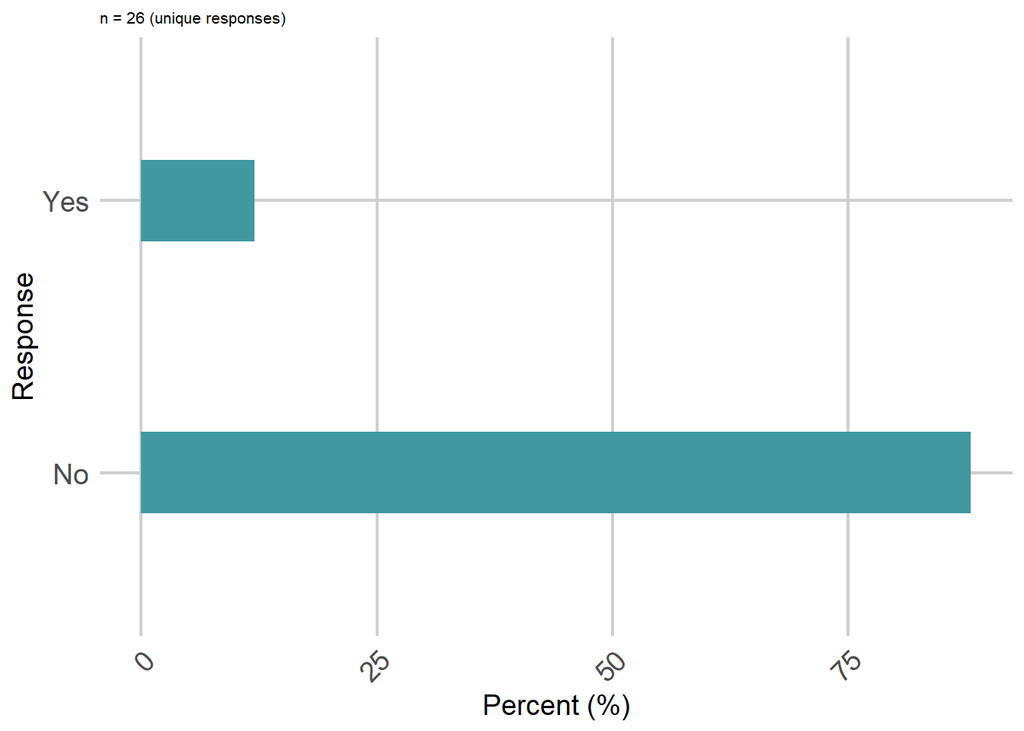

```r
summary <- dat %>%
  group_by(X23Disability) %>%
  filter(X23Disability != "") %>%
  summarise(count=n()) %>%
  mutate(X23Disability_perc = (count/sum(count))*100)

ggplot(summary %>%
         select(X23Disability_perc, X23Disability),
         aes(x=X23Disability_perc, y=X23Disability)) +
  geom_bar(stat="identity", width = 0.3, fill="#4198A1")+
  labs(
    x="Percent (%)",
    y="Response",
    subtitle="n = 26 (unique responses)"
  )+
  plotTheme12ptY
```